# Pairs Trading with Asset Ratios

## Pairs Trading with Asset Ratios

### I. Motivation

#### (a). Copper / Gold v.s. 10 Year Treasury

Copper gold ratio is often regarded as a very relavant indicator for understanding the 10 year treasury yield moves (there is indeed some correlation and I'll list below). The intutition is clear: copper is a very useful kind of industrial material. It is essential to the economic engine and thus the demand / price of which can be used to gauge the health of the ecnonomy. If things are booming, people buy a lot of copper and its price picks up. If there's a recession, the contrary is true. While for gold the opposite usually holds as it is one of the popular safe heaven assets. So the ratio of copper, gold prices is procyclical. Now we also know something about 10 year treasury. It is also considered as a kind of safe asset so the yield of which is therefore procyclical as well. Intuitively speaking, these two indicators should have some relavance with each other:

```python
print(f"Copper gold ratio and 10 year yield correation: {np.corrcoef(df['copper_gold_ratio'], df['t10_yield'].values)[0][1]}")
```

```
Copper gold ratio and 10 year yield correation: 0.6595793358698493
```

#### (b). Copper / Gold v.s. 30 Year Treasury / 10 Year Treasury

There are other things we can say about the copper gold ratio too. We may consider Copper as a kind of expected future cash flows as people buy it because they think they can use it to produce something that can bring in money in the future. For gold, as mentioned in the assginment document, it can be considered as a zero coupon bond -- or a kind of risk-free discounting factor. So taking the ratio of copper to gold is trying to get something like "discounted future economic expectation".

Now if we replace copper with 30 year treausry and gold with 10 year treasury, we may reach to a similar kind of conclusion.

And the two ratios also have a high correlation like above and they are of similar scale:

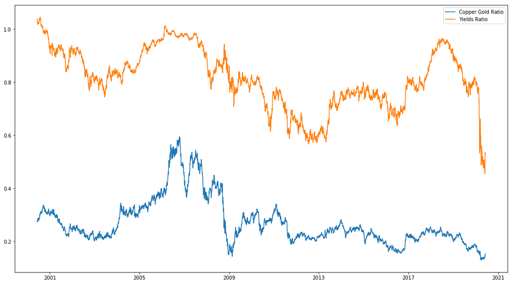

```python
dates = pd.to_datetime(df['date'], format='%Y-%m-%d').values

plt.figure(figsize=(18, 10))
plt.plot(dates, df['copper_gold_ratio'].values)
plt.plot(dates, df['t10_t30_yield_ratio'].values)
plt.legend(['Copper Gold Ratio', 'Yields Ratio'])
plt.show()
```

I used yields instead of prices because of the tradition from (a) and also because the price ratios are less correlated.

One thing we can notice from the above chart is that the spread between these two ratios seems to always wander around a cetain range. It looks mean-reverting:

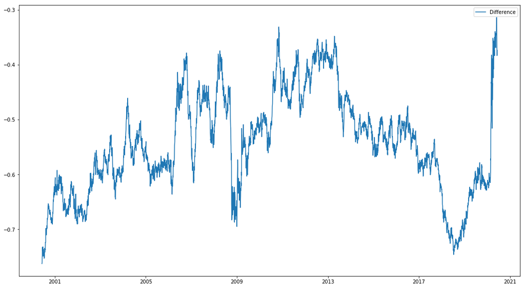

```python
plt.figure(figsize=(18, 10))
plt.plot(dates, (df['copper_gold_ratio'] - df['t10_t30_yield_ratio']).values)
plt.legend(['Difference'])
plt.show()
```

### II. Some Statistics

In this section I'm going to do some more rigorous tests on the two ratio time series. But first, I have to introduce a bit of theories on cointegration.

Please see page 153 ~ 212 in the attached slides on the introduction of unit-root nonstationarity and cointegration. It also talks about how to test for cointegration relationship and if there exists one, how to use Error Correction Model to extract the linear stationary components (cointegrating vectors). These are the theoretical basis for the analysis or test that follows.

If you are familiar with the concepts, you can just skip them and jump to the tests part.

#### (a). Cointegration

As sketched out in the slides, the first step checking the cointegration relation between two time series is to do some unit-root tests on each individual time seires. The point being, if they are statinary already, one can just study these series directly. The usual situation would be both time series are non-stationary, something like I(1) processes (or, random walks) and taking the first difference would make them stationary. If this is the case, one can then proceed to check if there's a linear combination of these two that is also stationary, i.e.: if they are cointegrated. The test I will be using here is the augmented Engle-Granger two-step cointegration test. It's a standard procedure and has been implemented in Python statsmodels.

```python
# Augmented Dickey–Fuller test for stationarity checking:
print("Stationarity test for ratio time series: ")
print(f'copper/gold p-value: {adfuller(df.copper_gold_ratio.values, regression="ct")[1]}')
print(f't10/t30 p-value: {adfuller(df.t10_t30_yield_ratio.values, regression="ct")[1]}')

print("\nStationarity test for differenced ratio time series: ")
print(f'copper/gold p-value: {adfuller(df.copper_gold_ratio.diff().dropna().values, regression="ct")[1]}')
print(f't10/t30 p-value: {adfuller(df.t10_t30_yield_ratio.diff().dropna().values, regression="ct")[1]}')
```

```
Stationarity test for ratio time series:
copper/gold p-value: 0.3022023347123951
t10/t30 p-value: 0.5476454574443721

Stationarity test for differenced ratio time series:
copper/gold p-value: 2.735535972496745e-18
t10/t30 p-value: 1.4454045734006337e-22
```

So they are I(1) processes. And here the cointegration test comes:

```python
# Augmented Engle-Granger two-step cointegration test:
result = ts.coint(df.copper_gold_ratio.values, df.t10_t30_yield_ratio.values)
print(f't-statistic: {result[0]}')
print(f'p-value: {result[1]}')
print(f'critical-values: 1% {result[2][0]}, 5% {result[2][1]}, 10% {result[2][2]}')
```

```
t-statistic: -3.185137842099995
p-value: 0.07244861023964706
critical-values: 1% -3.89863172108, 5% -3.33735229292, 10% -3.0452983488
```

#### (a). ECM

Now that they are cointegrated, what's left to do is to extract the cointegrating vector and double check it is indeed stationary. Here I use the Error Correction Model for the combined 2 dimensional process $R_{t}$:

$$ \Delta R_{t} = \mu_t + \Pi R_{t-1} + \Phi_1^* \Delta R_{t-1} + ... + \Phi_p^* \Delta R_{t - p + 1} + \epsilon_{t} \tag{1} $$

where $\Pi$ admits a decomposition $\Pi = \alpha \beta^{'}$.

So we want to find $\beta$, or more precisely, find $w_t = \beta^{'} R_{t}$:

```python
# Vector Error Correction Model:
df_vecm = df[['copper_gold_ratio', 't10_t30_yield_ratio']]
model = VECM(df_vecm.values).fit()
model.summary()
```

Det. terms outside the coint. relation & lagged endog. parameters for equation y1

|  | coef | std err | z | P>\|z\| | [0.025 | 0.975] |
| --- | --- | --- | --- | --- | --- | --- |
| L1.y1 | -0.0747 | 0.014 | -5.226 | 0.000 | -0.103 | -0.047 |
| L1.y2 | 0.0352 | 0.010 | 3.388 | 0.001 | 0.015 | 0.056 |

Det. terms outside the coint. relation & lagged endog. parameters for equation y2

|  | coef | std err | z | P>\|z\| | [0.025 | 0.975] |
| --- | --- | --- | --- | --- | --- | --- |
| L1.y1 | -0.0282 | 0.020 | -1.429 | 0.153 | -0.067 | 0.010 |
| L1.y2 | -0.0047 | 0.014 | -0.330 | 0.741 | -0.033 | 0.023 |

Loading coefficients (alpha) for equation y1

|  | coef | std err | z | P>\|z\| | [0.025 | 0.975] |
| --- | --- | --- | --- | --- | --- | --- |
| ec1 | -0.0014 | 0.001 | -1.560 | 0.119 | -0.003 | 0.000 |

Loading coefficients (alpha) for equation y2

|  | coef | std err | z | P>\|z\| | [0.025 | 0.975] |
| --- | --- | --- | --- | --- | --- | --- |
| ec1 | 0.0024 | 0.001 | 1.913 | 0.056 | -5.9e-05 | 0.005 |

Cointegration relations for loading-coefficients-column 1

|  | coef | std err | z | P>\|z\| | [0.025 | 0.975] |
| --- | --- | --- | --- | --- | --- | --- |
| beta.1 | 1.0000 | 0 | 0 | 0.000 | 1.000 | 1.000 |
| beta.2 | -0.3649 | 0.034 | -10.691 | 0.000 | -0.432 | -0.298 |

The betas are listed in the last summary table. They are highly statistical significant as you can see from the p-values.

Now to extract conintegrating vector and test for stationarity:

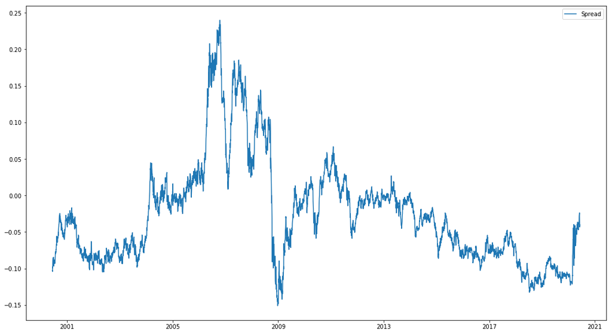

```
Cointegrating vector p-value: 0.08207619353190282
```

```python
# Stationarity test for cointegrating vector:
coint_vector = np.squeeze(np.dot(df_vecm.values, model.beta))

plt.figure(figsize=(18, 10))
plt.plot(dates, coint_vector)
plt.legend(['Spread'])
plt.show()
print(f'Cointegrating vector p-value: {adfuller(coint_vector, regression="ct")[1]}')
```

Although it looks a bit suspicious but it is indeed stationary.

### III. Strategy

So the idea is very straightforward. We model the spread of ratios as a mean-reverting time series and continuously monitor its values. If someday it breaks the upper non-trivial bound, we short the spread, and when it comes back to the trivial bound in the future, we close the position. And vice versa. By trivial or non-trivial bounds, I mean:

$$ mean:\ \mu,\ standard\ deviation:\ std \\ trivial\ bounds:\ [\mu - 0.5 * std,\ \mu + 0.5 * std] \\ one\ sigma\ bounds:\ [\mu - std,\ \mu + std] \\ two\ sigma\ bounds:\ [\mu - 2 * std,\ \mu + 2 * std] \\ three\ sigma\ bounds:\ [\mu - 3 * std,\ \mu + 3 * std] \\ $$

When the spread lives in the trivial bounds, we do nothing, when it for instance breaks the upper trivial bound and continues moving upward and breaks the one sigma upper bound, we open 1 sythetic short position, if two sigma bound then 2 sythetic positions and etc. I have no time to plot out the charts here but I hope this has lived in your imagination.

There's one difficulty that exists here. That is about the spread. Its's a difference of ratios, it's something non-tradable. I figured out a way to get around this by using first order approximation to produce a some kind of synthetic trade that replicates 1 unit of spread:

Let $f(a, b, c, d) = \frac{a}{b} - \frac{c}{d}$, take the first order approximation to be:

$$ df(a, b, c, d) = f_{a} da + f_{b} db + f_{c} dc + f_{d} dd $$

To produce 1 unit of $f$, we can take $\frac{1}{4f_{a}}$ a, $\frac{1}{4f_{b}}$ b, $\frac{1}{4f_{c}}$ c, $\frac{1}{4f_{d}}$ d. All derivatives can be calculated correspondingly. For example, let 10 year yield be $y$, 30 year be $z$ and Modefied Duration be ModdD, we have:

$$ \frac{\partial f}{\partial P} = \frac{\frac{\partial f}{\partial y}}{\frac{\partial P}{\partial y}} = - \frac{1}{P*ModD*z_{t}} $$

And I took $\frac{1}{4}$ purey for the simplicity. One can of course say replace this number with some kind of function of the rolling correlations between $f$ and the individual contributor. But that is too complex and not necessary here since the synthesis itself is largely an approximation because I have ommitted all those higher order derivatives and one can hardly argue that these four assets live in four independent spaces.

### IV. Backtesting

Here are some parameters that I set for the experiment:

**Initial capital**: 10 million,  
**Trasaction cost**: 0.0025,  
**Initial margin rate**: 0.15,  
**Average repo rate**: 0.0174,  
**Stop loss**: -0.2,  
**Risk free rate**: 0.025

For simplicity, I assumed ample capital so there's no margin calls. And I used the average repo rate for shorting treasuries.

#### I. Systematic Deals:

$$ 10\ Year\ Treasury:\ -\frac{y_{30} \times P_{10} \times ModD_{10}}{4} \\ 30\ Year\ Treasury:\ \frac{y_{30}^2 \times P_{30} \times ModD_{30}}{4 \times y_{10}} \\ Copper:\ -\frac{P_{gold}}{4 \times \beta} \\ Gold:\ \frac{P_{gold}^2}{4 \times \beta \times P_{copper}} $$

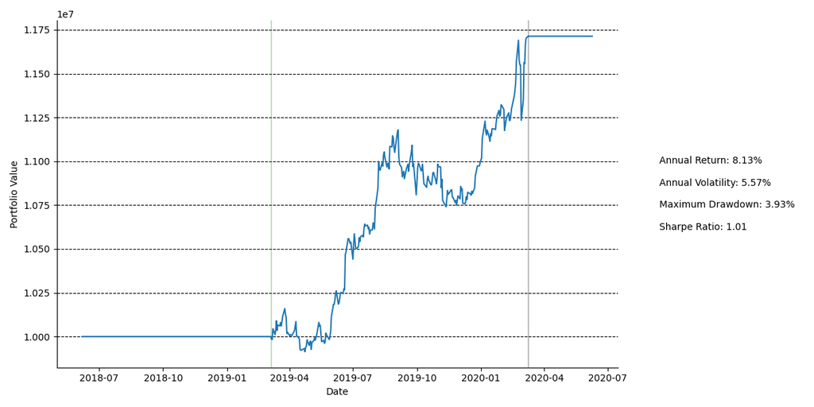

```python
# systematic
```

#### II. Discretionary Deals:

In this test period, there was not much trade happening. There was a strong long-term mean reverting trend for the spread and in this case one may as well simply follow it by going into some discretionary bets with gold:

$$ 10\ Year\ Treasury:\ 0 \\ 30\ Year\ Treasury:\ 0 \\ Copper:\ 0 \\ Gold:\ 6666 $$

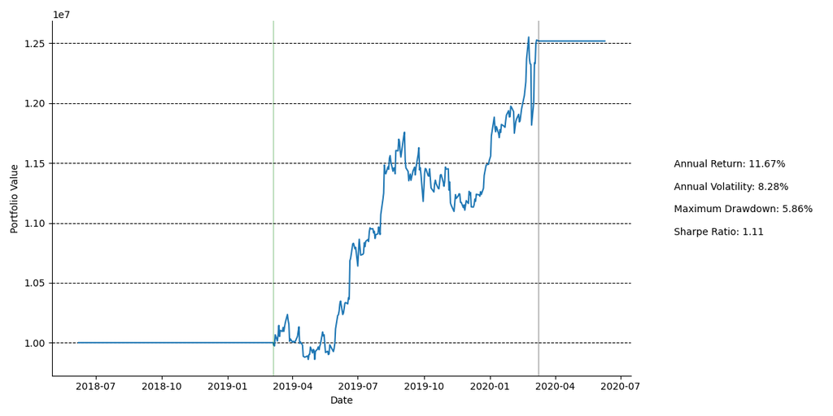

```python
# discretionary gold
```

We can also include 10 year treasury as a hedge:

$$ 10\ Year\ Treasury:\ 6666 \\ 30\ Year\ Treasury:\ 0 \\ Copper:\ 0 \\ Gold:\ 6666 $$

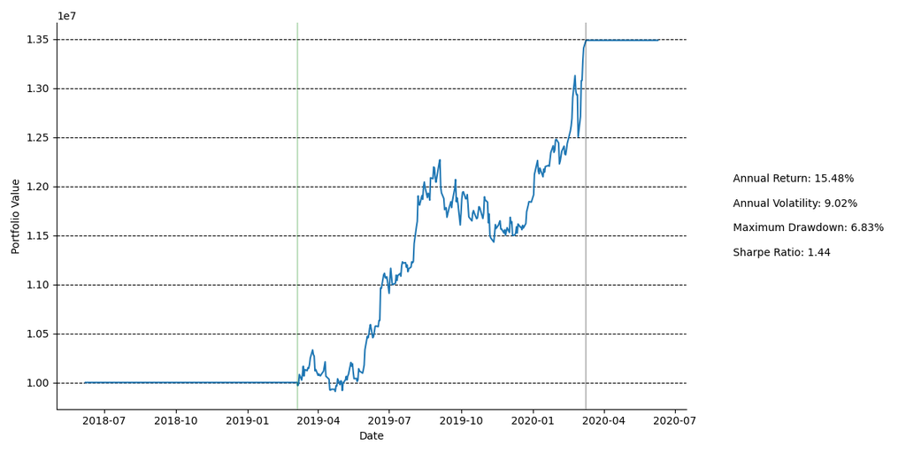

```python
# discretionary gold and 10 year treasury
```